# Convolutional Neural Networks

# Keagan DeLong

*Some of content of this notebook has been modified by, optimized by, and/or generated using GPT4.*

*No provided code was used*

## Convolutional Neural Networks Introduction

Convolutional Neural Networks (CNNs) are a class of deep neural networks that are primarily used for image and video recognition tasks. They have become one of the most popular and powerful techniques in computer vision due to their ability to automatically learn and extract hierarchical features from images.

CNNs consist of multiple layers of interconnected neurons, each of which performs a specific task. The core building blocks of CNNs are convolutional layers, which apply a set of learnable filters to the input image to extract features. These filters slide over the input image and perform a dot product operation to generate a feature map. The output of a convolutional layer is then passed through an activation function to introduce non-linearity.

In addition to convolutional layers, CNNs typically include other types of layers such as pooling layers, which reduce the spatial size of the feature maps, and fully connected layers, which perform classification based on the extracted features.

Training a CNN involves feeding it a large dataset of labeled images and adjusting the weights of the filters to minimize the difference between the predicted and actual labels. This is typically done using backpropagation and stochastic gradient descent.

CNNs have been used for a wide range of applications such as object detection, image segmentation, and style transfer, and have achieved state-of-the-art results on many benchmarks in computer vision. They have also been applied to other domains such as natural language processing and speech recognition with some success.

## Bonus Model Introduction

ResNet18 is a type of convolutional neural network (CNN) that was introduced in 2015 as part of the ResNet family of models. It is a relatively small and shallow network, consisting of 18 layers, and is designed to be computationally efficient while still achieving high accuracy on image recognition tasks.

The key innovation of ResNet18 is the use of residual connections, which allow the network to learn residual functions that can be added to the input to produce the output. These connections help to mitigate the vanishing gradient problem that can occur in deep neural networks and allow the network to be trained more easily and effectively.

ResNet18 consists of several convolutional layers followed by a global average pooling layer and a fully connected layer for classification. The convolutional layers are organized into four groups, with each group consisting of several residual blocks. Each residual block contains two or three convolutional layers and a residual connection that bypasses the convolutional layers.

During training, ResNet18 is typically initialized with pre-trained weights from a larger model, such as ResNet50 or ResNet101, and fine-tuned on the target dataset. This transfer learning approach has been shown to be effective in reducing training time and improving performance on a wide range of image recognition tasks.

ResNet18 has been widely used as a baseline architecture for image recognition tasks, and has achieved state-of-the-art results on several benchmarks such as CIFAR-10 and ImageNet. Its small size and high accuracy make it a popular choice for embedded systems and mobile applications where computational resources are limited.

## PyTorch CUDA Setup

To verify that PyTorch is running with CUDA enabled on the system the following commands are run:

`nvidia-smi` This command runs the NVIDIA System Management Interface (nvidia-smi) to display information about the NVIDIA GPUs installed on the system. This includes information such as the GPU's utilization, memory usage, and temperature.

`nvcc --version` This command that runs the NVIDIA CUDA Compiler (nvcc) to display the version of the CUDA toolkit installed on the system. CUDA is a parallel computing platform that is used to accelerate computations on NVIDIA GPUs.

`torch.cuda.is_available()` This checks if your GPU driver and CUDA is enabled and accessible by PyTorch

`torch.version.cuda` Returns a string containing the version number of the installed CUDA toolkit. If PyTorch is built with CUDA support, this attribute will return the version of the CUDA toolkit that was used during the PyTorch build process. If PyTorch is not built with CUDA support, this attribute will raise an error. **The version of CUDA you want to use with PyTorch must match the version it was built with.**

`torch.cuda.current_device()` This prints the index of the current CUDA device being used by PyTorch. If multiple GPUs are available on the system, this will indicate which one is currently being used.

`torch.cuda.get_device_name` This prints the name of the current CUDA device being used by PyTorch. This will typically be the name of the GPU manufacturer and model.

```python
!nvidia-smi
!nvcc --version
import torch.cuda
print(f"CUDA Available?: {torch.cuda.is_available()}\n")
print(f"PyTorch CUDA Version: {torch.version.cuda}\n")
print(f"CUDA Device #: {torch.cuda.current_device()}\n")
print(f"GPU Name: {torch.cuda.get_device_name(torch.cuda.current_device())}\n")
```

```
Sun Apr 16 16:02:52 2023
+---------------------------------------------------------------------------------------+
| NVIDIA-SMI 531.61                 Driver Version: 531.61       CUDA Version: 12.1     |
|-----------------------------------------+----------------------+----------------------+
| GPU  Name                      TCC/WDDM | Bus-Id        Disp.A | Volatile Uncorr. ECC |
| Fan  Temp  Perf            Pwr:Usage/Cap|         Memory-Usage | GPU-Util  Compute M. |
|                                         |                      |               MIG M. |
|=========================================+======================+======================|
|   0  NVIDIA GeForce RTX 3080 Ti    WDDM | 00000000:01:00.0  On |                  N/A |
|  0%   44C    P8               31W / 385W|    758MiB / 12288MiB |      3%      Default |
|                                         |                      |                  N/A |
+-----------------------------------------+----------------------+----------------------+

+---------------------------------------------------------------------------------------+
| Processes:                                                                            |
|  GPU   GI   CI        PID   Type   Process name                            GPU Memory |
|        ID   ID                                                             Usage      |
|=======================================================================================|
|    0   N/A  N/A      4464    C+G   ...__8wekyb3d8bbwe\Microsoft.Notes.exe    N/A      |
|    0   N/A  N/A      6100    C+G   ...ekyb3d8bbwe\PhoneExperienceHost.exe    N/A      |
|    0   N/A  N/A      7304    C+G   ...e Stream\73.0.4.0\GoogleDriveFS.exe    N/A      |
|    0   N/A  N/A      8800    C+G   ...oogle\Chrome\Application\chrome.exe    N/A      |
|    0   N/A  N/A     10788    C+G   ... Synapse 3 Host\Razer Synapse 3.exe    N/A      |
|    0   N/A  N/A     11404    C+G   ...t.LockApp_cw5n1h2txyewy\LockApp.exe    N/A      |
|    0   N/A  N/A     12056    C+G   ...2txyewy\StartMenuExperienceHost.exe    N/A      |
|    0   N/A  N/A     13016    C+G   ...__8wekyb3d8bbwe\WindowsTerminal.exe    N/A      |
|    0   N/A  N/A     14868    C+G   C:\Windows\explorer.exe                   N/A      |
|    0   N/A  N/A     15660    C+G   ...nt.CBS_cw5n1h2txyewy\SearchHost.exe    N/A      |
|    0   N/A  N/A     17468    C+G   ...siveControlPanel\SystemSettings.exe    N/A      |
+---------------------------------------------------------------------------------------+
nvcc: NVIDIA (R) Cuda compiler driver
Copyright (c) 2005-2022 NVIDIA Corporation
Built on Wed_Sep_21_10:41:10_Pacific_Daylight_Time_2022
Cuda compilation tools, release 11.8, V11.8.89
Build cuda_11.8.r11.8/compiler.31833905_0
CUDA Available?: True

PyTorch CUDA Version: 11.8

CUDA Device #: 0

GPU Name: NVIDIA GeForce RTX 3080 Ti
```

This code is a PyTorch implementation of a deep learning pipeline for image classification. It includes a custom convolutional neural network (CNN) architecture, data loading and preprocessing, model training and evaluation, and hyperparameter optimization using Optuna. Additionally, it uses Weights & Biases (wandb) for experiment tracking and logging.

Here's a summary of the key components:

The code is designed to run an image classification task on either the MNIST or CIFAR100 dataset using either the custom CNN or a pre-trained ResNet18 model. The pipeline includes data augmentation, hyperparameter optimization, early stopping, and evaluation on a held-out test set. The model's performance and other statistics are logged using Weights & Biases.

## Custom CNN Architecture

This model is a custom Convolutional Neural Network (CNN) designed for image classification tasks. The architecture consists of the following components:

1. `Swish` class: A custom activation function defined as Swish(x) = x * sigmoid(x), where x is the input tensor, and sigmoid is the sigmoid activation function. Swish is known to work well in deep neural networks by providing better gradient flow.
2. `CustomCNN` class: The main CNN model class that inherits from the nn.Module class of PyTorch.

The model has the following structure:

- `conv_layers`: A sequence of convolutional layers composed of three blocks with:
  - Two convolutional layers (Conv2d) with **batch normalization** (BatchNorm2d) and Swish activation function. Each block doubles the number of output channels from the previous block (32, 64, and 128).
  - **Max-pooling** layer (MaxPool2d) with a kernel size of 2 and a stride of 2 to reduce the spatial dimensions.
  - Dropout layer (Dropout) with a dropout rate of 0.5 for regularization. An average pooling layer (AvgPool2d) with a kernel size of 3 and a stride of 3 to reduce the spatial dimensions further.
- `fc_layers`: A sequence of fully connected layers composed of:
  - A linear layer (Linear) with an input size of 128 and output size of 256, followed by the Swish activation function and a dropout layer (Dropout) with a dropout rate of 0.5.
  - A linear layer (Linear) with an input size of 256 and output size of 10, corresponding to the number of classes in the classification problem.
- `forward` function: The forward pass of the network that takes an input tensor x and passes it through the conv_layers and fc_layers. The final output is passed through the softmax activation function to obtain class probabilities.

```python
import torch
import torch.nn as nn
import torch.nn.functional as F

class Swish(nn.Module):
    def forward(self, x):
        return x * torch.sigmoid(x)

# Custom CNN class
class CustomCNN(nn.Module):
    def __init__(self):
        super(CustomCNN, self).__init__()
        self.conv_layers = nn.Sequential(
            nn.Conv2d(1, 32, 3, padding=1, stride=1),
            nn.BatchNorm2d(32),
            Swish(),
            nn.Conv2d(32, 32, 3, padding=1, stride=1),
            nn.BatchNorm2d(32),
            Swish(),
            nn.MaxPool2d(2, 2),
            nn.Dropout(0.5),

            nn.Conv2d(32, 64, 3, padding=1, stride=1),
            nn.BatchNorm2d(64),
            Swish(),
            nn.Conv2d(64, 64, 3, padding=1, stride=1),
            nn.BatchNorm2d(64),
            Swish(),
            nn.MaxPool2d(2, 2),
            nn.Dropout(0.5),

            nn.Conv2d(64, 128, 3, padding=1, stride=1),
            nn.BatchNorm2d(128),
            Swish(),
            nn.Conv2d(128, 128, 3, padding=1, stride=1),
            nn.BatchNorm2d(128),
            Swish(),
            nn.MaxPool2d(2, 2),
            nn.Dropout(0.5),

            nn.AvgPool2d(3, 3)
        )

        self.fc_layers = nn.Sequential(
            nn.Linear(128, 256),
            Swish(),
            nn.Dropout(0.5),

            nn.Linear(256, 10),
        )

    def forward(self, x):
        x = self.conv_layers(x)
        x = x.view(x.size(0), -1)

        x = self.fc_layers(x)
        return F.softmax(x, dim=1)
```

## CustomResNet18-Based Architecture

*This model does not achieve good test accuracy and I ran out of time for development*

This model, `CustomResNet18`, is a custom neural network that extends the PyTorch `nn.Module` class. The model is built on top of the pre-trained ResNet18 architecture, and it is designed for image classification tasks with a specified number of classes (`num_classes`).

Here's a description of the components of the CustomResNet18 model:

1. `resnet = resnet18(weights=ResNet18_Weights.IMAGENET1K_V1)`: Load a pre-trained ResNet18 model with ImageNet weights.
2. `self.backbone`: Remove the last fully connected layer and global average pooling from the pre-trained ResNet18 model to use as a feature extractor.
3. `self.additional_conv_layers`: Add additional convolutional layers to the model. These layers include a 2D convolution, a scaled exponential linear unit (SELU) activation function, batch normalization, and dropout with a rate of 0.5.
4. `self.avgpool`: Add an adaptive average pooling layer that reduces the spatial dimensions to 1x1.
5. `self.fc_layers`: Define the fully connected layers, which include a linear layer with 256 output units, a SELU activation function, dropout with a rate of 0.5, and another linear layer that outputs the number of classes.
6. `forward()`: Implement the forward pass of the model, which takes an input x, passes it through the backbone, the additional convolutional layers, the adaptive average pooling, and reshapes the tensor before passing it through the fully connected layers. Finally, apply the softmax activation function along dimension 1 to generate class probabilities.

In summary, the `CustomResNet18` model is a custom image classification model based on the pre-trained ResNet18 architecture, with additional convolutional layers, SELU activation functions, batch normalization, dropout, and fully connected layers.

```python
import torch
import torch.nn as nn
import torch.nn.functional as F
from torchvision.models.resnet import resnet18
from torchvision.models.resnet import ResNet18_Weights

class CustomResNet18(nn.Module):
    def __init__(self, num_classes=100):
        super(CustomResNet18, self).__init__()

        # Load the pre-trained ResNet18 model
        resnet = resnet18(weights=ResNet18_Weights.IMAGENET1K_V1)

        # Remove the last fully connected layer and global average pooling to use as a feature extractor
        self.backbone = nn.Sequential(*list(resnet.children())[:-2])

        # Add additional convolutional layers with SELU activation, normalization, and dropout
        self.additional_conv_layers = nn.Sequential(
            nn.Conv2d(512, 512, kernel_size=3, padding=1),
            nn.SELU(),
            nn.BatchNorm2d(512),
            nn.Dropout(0.5)
        )

        self.avgpool = nn.AdaptiveAvgPool2d((1, 1))

        self.fc_layers = nn.Sequential(
            nn.Linear(512, 256),
            nn.SELU(),
            nn.Dropout(0.5),
            nn.Linear(256, num_classes),
        )

    def forward(self, x):
        x = self.backbone(x)
        x = self.additional_conv_layers(x)
        x = self.avgpool(x)
        x = x.view(x.size(0), -1)
        x = self.fc_layers(x)
        return F.softmax(x, dim=1)
```

## Training, Evaluation, and Testing Pipeline

This code block is a complete script for training and evaluating various CNN models for image classification tasks on MNIST or CIFAR-100 datasets. The script is divided into several functions for dataset preparation, model training, evaluation, and hyperparameter optimization.

1. Import necessary libraries like PyTorch, torchvision, Optuna, and Weights & Biases (wandb).
2. Define the `get_datasets` function that returns the train and test datasets based on the provided dataset name ('MNIST' or 'CIFAR100') and data_transforms.
3. Define the `train_and_evaluate_model` function that trains the provided model on the train dataset and evaluates it on the validation dataset using the given hyperparameters. It also implements early stopping based on the patience parameter.
4. Define the evaluate function that calculates the accuracy of the provided model on a given DataLoader.
5. Define the `objective` function that is used by Optuna to optimize the hyperparameters. This function creates an instance of the model (CustomCNN, ResNet18, or CustomResNet18) based on the model_type and trains it using the train_and_evaluate_model function. It returns the validation accuracy.
6. Define the `main` function, which:
   - Sets up the device and random seeds.
   - Defines data augmentation and transformation for the selected dataset.
   - Retrieves the train and test datasets using get_datasets.
   - Splits the train dataset into train and validation sets using `random_split`.
   - Creates an instance of the selected model.
   - If `optimize_hyperparams` is True, uses Optuna to optimize the hyperparameters for the selected model by running multiple trials and selects the best hyperparameters.
   - Otherwise, manually sets the hyperparameters for the selected model.
   - Trains the final model with the best hyperparameters.
   - Evaluates the final model on the test dataset.
   - Prints and logs the test accuracy using wandb.

The script includes various best practices such as data augmentation, early stopping, and hyperparameter optimization. The primary goal of this script is to train and evaluate different CNN models on the MNIST or CIFAR-100 datasets, find the best hyperparameters, and report the test accuracy.

### Training & Evaluation

The `train_and_evaluate_model` function is designed to train a given neural network model on a training dataset and evaluate its performance on a validation dataset. The function takes the following arguments:

- `model`: The neural network model to train.
- `learning_rate`: The learning rate for the optimizer.
- `weight_decay`: The weight decay (L2 regularization) for the optimizer.
- `T_max`: The maximum number of epochs for the CosineAnnealingLR scheduler.
- `batch_size`: The batch size for the DataLoader.
- `num_epochs`: The total number of training epochs.
- `train_dataset`: The training dataset.
- `val_dataset`: The validation dataset.
- `device`: The device to run the model on (CPU or GPU).

Here's what the function does:

1. Creates DataLoaders for the training and validation datasets.
2. Moves the model to the specified device.
3. Defines the loss function (CrossEntropyLoss) and the optimizer (Adam) with the provided learning rate and weight decay.
4. Initializes the learning rate scheduler (CosineAnnealingLR) with the provided T_max.
5. Initializes variables for early stopping (best_val_loss, best_model, patience_count, and patience).
6. Trains the model for the specified number of epochs by iterating over the training dataset in batches. For each batch, it computes the loss, performs backpropagation, updates the model parameters, and logs the training loss to Weights & Biases (wandb).
7. Updates the learning rate scheduler after each epoch.
8. Evaluates the model on the validation dataset after each epoch by computing the total validation loss.
9. Implements early stopping based on the patience parameter. If the validation loss does not improve for a specified number of consecutive epochs (patience), it stops the training and returns the best model obtained so far.
10. Loads the best model's state dictionary.
11. Evaluates the final model on the validation dataset using the `evaluate` function and computes the validation accuracy.
12. Returns the validation accuracy and the trained model.

This function trains the input model using the provided hyperparameters and datasets, implements early stopping, and returns the best model along with its validation accuracy.

The `evaluate` function evaluates a given neural network model's performance on a dataset using a specified loss criterion and device. It takes the following arguments:

- `model`: The neural network model to evaluate.
- `data_loader`: A DataLoader object containing the dataset to evaluate the model on.
- `criterion`: The loss function to compute the model's loss.
- `device`: The device to run the model on (CPU or GPU).

Here's what the function does:

1. Sets the model to evaluation mode using `model.eval()`.
2. Initializes variables to track the number of correct predictions (`correct`), the total number of samples (`total`), and the total validation loss (`val_loss`).
3. Iterates over the dataset in batches using the DataLoader, with gradients disabled (`with torch.no_grad()`).
4. For each batch, moves the data and targets to the specified device and passes the data through the model to get the output predictions.
5. Computes the loss using the provided criterion and accumulates it in the `val_loss` variable.
6. Identifies the class with the highest predicted probability by using `torch.max` on the output predictions and compares the predicted classes with the true targets.
7. Updates the `total` variable with the number of samples in the current batch and increments the correct variable with the number of correct predictions.
8. After iterating through the entire dataset, computes the accuracy as the percentage of correct predictions over the total number of samples.
9. Returns the computed accuracy.

The `evaluate` function measures the performance of the input model on a given dataset by computing the accuracy (the percentage of correct predictions).

### Hyperparameter Tuning

The objective function is designed to be used with Optuna, a hyperparameter optimization library. The function trains and evaluates a specified model type with a given dataset using a set of hyperparameters suggested by Optuna, and returns the validation accuracy. The function accepts the following arguments:

- `trial`: An Optuna trial object that is responsible for suggesting hyperparameters for optimization.
- `model_type`: The type of neural network model to train (e.g., 'CustomCNN', 'ResNet18', 'CustomResNet18').
- `num_epochs`: The number of epochs to train the model.
- `train_dataset`: The dataset to use for training the model.
- `val_dataset`: The dataset to use for validating the model.
- `dataset`: The dataset name, used to determine the number of output classes for the model (e.g., 'CIFAR100').

Here's what the function does:

1. Determines the device to run the model on (GPU if available, otherwise CPU).
2. Instantiates the specified model type, either 'CustomCNN', 'ResNet18', or 'CustomResNet18'. If using 'ResNet18', it also modifies the final fully connected layer to match the number of output classes.
3. Moves the model to the specified device.
4. Uses the Optuna trial object to suggest hyperparameters for learning rate, weight decay, T_max (for CosineAnnealingLR scheduler), and batch size.
5. Calls the `train_and_evaluate_model` function with the suggested hyperparameters and provided datasets to train the model and compute its validation accuracy.
6. Returns the validation accuracy, which Optuna will use as the objective to optimize.

In summary, the objective function trains and evaluates a specified model using hyperparameters suggested by Optuna and returns the validation accuracy for the purpose of hyperparameter optimization.

```python
import torch
import torch.nn as nn
import torch.optim as optim
from torch.utils.data import DataLoader, random_split
import torchvision
from torchvision.models.resnet import ResNet18_Weights
from torchvision import datasets, transforms, models
from torch.optim.lr_scheduler import CosineAnnealingLR
import numpy as np
import optuna
import wandb


def get_datasets(dataset, data_transforms):
    if dataset == 'MNIST':
        train_data = datasets.MNIST(root="dataset/", train=True, transform=data_transforms, download=True)
        test_data = datasets.MNIST(root="dataset/", train=False, transform=data_transforms, download=True)
    elif dataset == 'CIFAR100':
        train_data = datasets.CIFAR100(root="dataset/", train=True, transform=data_transforms, download=True)
        test_data = datasets.CIFAR100(root="dataset/", train=False, transform=data_transforms, download=True)
    else:
      raise ValueError(f"Invalid dataset '{dataset}', supported datasets are 'MNIST' and 'CIFAR100'.")

    return train_data, test_data

# Define the train_and_evaluate_model function
def train_and_evaluate_model(model, learning_rate, weight_decay, T_max, batch_size, num_epochs, train_dataset, val_dataset, device):
    train_loader = DataLoader(dataset=train_dataset, batch_size=batch_size, shuffle=True)
    val_loader = DataLoader(dataset=val_dataset, batch_size=batch_size, shuffle=False)

    model = model.to(device)
    criterion = nn.CrossEntropyLoss()
    optimizer = optim.Adam(model.parameters(), lr=learning_rate, weight_decay=weight_decay)
    scheduler = CosineAnnealingLR(optimizer, T_max=T_max)

    best_val_loss = float('inf')
    best_model = None
    num_epochs_without_improvement = 0
    patience = 5

    for epoch in range(num_epochs):
        # Training
        model.train()
        for batch_idx, (data, targets) in enumerate(train_loader):
            data, targets = data.to(device), targets.to(device)
            scores = model(data)
            loss = criterion(scores, targets)
            optimizer.zero_grad()
            loss.backward()
            optimizer.step()

            # Log the training loss to wandb
            wandb.log({"Training Loss": loss.item()}, step=epoch * len(train_loader) + batch_idx)

        scheduler.step()

        # Evaluation
        model.eval()
        val_loss = 0
        with torch.no_grad():
            for data, targets in val_loader:
                data, targets = data.to(device), targets.to(device)
                outputs = model(data)
                loss = criterion(outputs, targets)
                val_loss += loss.item()

        # Early stopping and saving the best model
        if val_loss < best_val_loss:
            best_val_loss = val_loss
            best_model = model.state_dict()
            patience_count  = 0
        else:
            patience_count  += 1
            if patience_count == patience:
                break

    model.load_state_dict(best_model)

    # Evaluation on validation set
    val_accuracy = evaluate(model, val_loader, criterion, device)

    return val_accuracy, model

def evaluate(model, data_loader, criterion, device):
    model.eval()
    correct = 0
    total = 0
    val_loss = 0

    with torch.no_grad():
        for data, targets in data_loader:
            data, targets = data.to(device), targets.to(device)
            outputs = model(data)
            loss = criterion(outputs, targets)
            val_loss += loss.item()

            _, predicted = torch.max(outputs.data, 1)
            total += targets.size(0)
            correct += (predicted == targets).sum().item()

    accuracy = 100 * correct / total
    return accuracy

# Objective function for Optuna
def objective(trial, model_type, num_epochs, train_dataset, val_dataset, dataset):
    device = torch.device("cuda" if torch.cuda.is_available() else "cpu")

    if model_type == 'CustomCNN':
        model = CustomCNN()
    elif model_type == 'ResNet18':
        model = models.resnet18(weights=ResNet18_Weights.IMAGENET1K_V1)
        num_ftrs = model.fc.in_features
        model.fc = nn.Linear(num_ftrs, 100 if dataset == 'CIFAR100' else 10)
    elif model_type == 'CustomResNet18':
        model = CustomResNet18(num_classes=100 if dataset == 'CIFAR100' else 10)
    else:
        raise ValueError(f"Invalid model_type '{model_type}', supported model types are 'CustomCNN', 'ResNet18', and 'CustomResNet18'")

    model.to(device)
    learning_rate = trial.suggest_float("learning_rate", 1e-4, 1e-3, log=True)
    weight_decay = trial.suggest_float("weight_decay", 0, 1e-4)
    T_max = trial.suggest_int("T_max", 5, 20)
    batch_size = trial.suggest_categorical("batch_size", [32, 64, 128, 256])

    val_accuracy, _ = train_and_evaluate_model(model, learning_rate,
                                            weight_decay,
                                            T_max, batch_size,
                                            num_epochs,
                                            train_dataset,
                                            val_dataset,
                                            device)
    return val_accuracy


def main(optimize_hyperparams=False, model_type='CustomCNN', dataset='MNIST'):
    # Set up the device and random seeds
    device = torch.device('cuda' if torch.cuda.is_available() else 'cpu')
    torch.manual_seed(42)
    np.random.seed(42)

    # Data augmentation
    if dataset == 'MNIST':
        data_transforms = transforms.Compose([
            transforms.RandomResizedCrop(28, scale=(0.9, 1.1)),
            transforms.ToTensor()
        ])
    elif dataset == 'CIFAR100':
        data_transforms = transforms.Compose([
            transforms.Resize((224, 224)),
            transforms.RandomResizedCrop(224, scale=(0.9, 1.1)),
            transforms.RandomHorizontalFlip(),
            transforms.ToTensor(),
            transforms.Normalize(mean=[0.485, 0.456, 0.406], std=[0.229, 0.224, 0.225])
        ])

    # Define the datasets and dataloaders
    train_data, test_data = get_datasets(dataset, data_transforms)

    train_size = int(0.8 * len(train_data))
    val_size = len(train_data) - train_size
    train_dataset, val_dataset = random_split(train_data, [train_size, val_size])

    num_epochs = 50

    if model_type == 'CustomCNN':
        model = CustomCNN()
    elif model_type == 'ResNet18':
        model = models.resnet18(weights=ResNet18_Weights.IMAGENET1K_V1)
        num_ftrs = model.fc.in_features
        model.fc = nn.Linear(num_ftrs, 100 if dataset == 'CIFAR100' else 10)
    elif model_type == 'CustomResNet18':
        model = CustomResNet18(num_classes=100 if dataset == 'CIFAR100' else 10)
    else:
        raise ValueError(f"Invalid model_type '{model_type}', supported model types are 'CustomCNN', 'ResNet18', and 'CustomResNet18'")

    if optimize_hyperparams:
        study = optuna.create_study(direction="maximize")
        study.optimize(lambda trial: objective(trial, model_type, num_epochs, train_dataset, val_dataset, dataset), n_trials=6)

        # Get the best hyperparameters
        best_hyperparams = study.best_params

    # Manually set hyperparameters
    elif model_type == 'CustomCNN':
        best_hyperparams = {
            "learning_rate": 0.001,
            "weight_decay": 1e-4,
            "T_max": 10,
            "batch_size": 64
        }
    elif model_type == 'ResNet18':
        best_hyperparams = {
            "learning_rate": 2e-4,
            "weight_decay": 7.460142260405703e-05,
            "T_max": 16,
            "batch_size": 512
        }
    elif model_type == 'CustomResNet18':
        best_hyperparams = {
            "learning_rate": 0.001,
            "weight_decay": 1e-4,
            "T_max": 10,
            "batch_size": 64
        }

    # Train the final model with the best hyperparameters
    if model_type == 'CustomCNN':
        model = CustomCNN()
    elif model_type == 'ResNet18':
        model = models.resnet18(weights=ResNet18_Weights.IMAGENET1K_V1)
        num_ftrs = model.fc.in_features
        model.fc = nn.Linear(num_ftrs, 100 if dataset == 'CIFAR100' else 10)
    elif model_type == 'CustomResNet18':
        model = CustomResNet18(num_classes=100 if dataset == 'CIFAR100' else 10)
    else:
        raise ValueError(f"Invalid model_type '{model_type}', supported model types are 'CustomCNN', 'ResNet18', and 'CustomResNet18'")

    val_accuracy, final_model = train_and_evaluate_model(model, best_hyperparams["learning_rate"],
                                              best_hyperparams["weight_decay"],
                                              best_hyperparams["T_max"],
                                              best_hyperparams["batch_size"],
                                              num_epochs, train_dataset, val_dataset, device)

    # Evaluate the final model on the test dataset
    test_loader = DataLoader(dataset=test_data, batch_size=best_hyperparams["batch_size"], shuffle=False)
    test_accuracy = evaluate(final_model, test_loader, nn.CrossEntropyLoss(), device)

    # Print and log test accuracy
    print(f"Test Accuracy: {test_accuracy}%")
    wandb.log({"Test Accuracy": test_accuracy})
    wandb.finish()
```

```python
# plot config
%matplotlib inline
%config InlineBackend.figure_format = 'retina'
import matplotlib as mpl
mpl.rcParams['figure.dpi'] = 120
```

### Custom CNN & MNIST Run

```python
if __name__ == "__main__":
    wandb.init(project="cnn_experiment")
    main(optimize_hyperparams=True, model_type='CustomCNN', dataset='MNIST')
```

Finishing last run (ID:a22g5bxx) before initializing another...

Waiting for W&B process to finish... **(success).**

Run history:

| Training Loss | ▆▄▄▇▅▁▆▅▆▇▅▇▆█▅▂▆▆▄▄▅▅▅▅██▇▅▇▆▇▆▅▆▇▇▅▆▅▆ |
| --- | --- |

Run summary:

| Training Loss | 4.59506 |
| --- | --- |

View run **dutiful-violet-95** at: https://wandb.ai/kndelong/cnn_experiment/runs/a22g5bxx  
Synced 6 W&B file(s), 0 media file(s), 0 artifact file(s) and 0 other file(s)

Find logs at: `.\wandb\run-20230416_175910-a22g5bxx\logs`

Successfully finished last run (ID:a22g5bxx). Initializing new run:

Tracking run with wandb version 0.14.2

Run data is saved locally in `C:\Users\keagan\wandb\run-20230416_180002-nx2e7jmt`

Syncing run **[stellar-voice-96](https://wandb.ai/kndelong/cnn_experiment/runs/nx2e7jmt)** to [Weights & Biases](https://wandb.ai/kndelong/cnn_experiment) ([docs](https://wandb.me/run))

View project at https://wandb.ai/kndelong/cnn_experiment

View run at https://wandb.ai/kndelong/cnn_experiment/runs/nx2e7jmt

```
[I 2023-04-16 18:00:09,867] A new study created in memory with name: no-name-8a5d4758-f67f-4a63-aedc-ac31e1b332b0
[I 2023-04-16 18:05:05,505] Trial 0 finished with value: 99.33333333333333 and parameters: {'learning_rate': 0.0009718174666331939, 'weight_decay': 3.0448117726034488e-05, 'T_max': 19, 'batch_size': 256}. Best is trial 0 with value: 99.33333333333333.
[I 2023-04-16 18:08:11,940] Trial 1 finished with value: 98.925 and parameters: {'learning_rate': 0.0007259962780975849, 'weight_decay': 7.816172415002908e-05, 'T_max': 5, 'batch_size': 32}. Best is trial 0 with value: 99.33333333333333.
[I 2023-04-16 18:17:15,095] Trial 2 finished with value: 99.16666666666667 and parameters: {'learning_rate': 0.00011934155054737243, 'weight_decay': 6.228672531521828e-05, 'T_max': 14, 'batch_size': 256}. Best is trial 0 with value: 99.33333333333333.
[I 2023-04-16 18:20:35,064] Trial 3 finished with value: 99.09166666666667 and parameters: {'learning_rate': 0.0009270759129740189, 'weight_decay': 9.437091950635884e-05, 'T_max': 10, 'batch_size': 128}. Best is trial 0 with value: 99.33333333333333.
[I 2023-04-16 18:23:05,220] Trial 4 finished with value: 98.85 and parameters: {'learning_rate': 0.0007514714742647626, 'weight_decay': 5.7752041828103486e-05, 'T_max': 5, 'batch_size': 64}. Best is trial 0 with value: 99.33333333333333.
[I 2023-04-16 18:28:18,370] Trial 5 finished with value: 99.38333333333334 and parameters: {'learning_rate': 0.0002621158385125376, 'weight_decay': 8.256717067014993e-05, 'T_max': 19, 'batch_size': 64}. Best is trial 5 with value: 99.38333333333334.
```

```
Test Accuracy: 99.5%
```

Waiting for W&B process to finish... **(success).**

Run history:

| Test Accuracy | ▁ |
| --- | --- |
| Training Loss | ▄▄▂▂▂▁▂▂▂▂▂▆▁▃▁▁▄▂▁▆▁▁▂▁▁▂▁▁▁▄▁▁▁▂█▂▁▁▁▃ |

Run summary:

| Test Accuracy | 99.5 |
| --- | --- |
| Training Loss | 1.46493 |

View run **stellar-voice-96** at: https://wandb.ai/kndelong/cnn_experiment/runs/nx2e7jmt  
Synced 6 W&B file(s), 0 media file(s), 0 artifact file(s) and 0 other file(s)

Find logs at: `.\wandb\run-20230416_180002-nx2e7jmt\logs`

`optimize_hyperparameters` is set to true in this run of the experiment in order to maximize the potential to increase the test accuracy.

Below has the best parameters found by the Optuna objective function:

```
Trial 5 finished with value: 99.38333333333334 and parameters:

{'learning_rate': 0.0002621158385125376,
'weight_decay': 8.256717067014993e-05,
'T_max': 19, 'batch_size': 64}.

Best is trial 5 with value: 99.38333333333334
```

The number of iterations of tuning is limited to 6 in order to save time. The highest achieved accuracy for the `CustomCNN` model is 99.5% on the test set. The links to W&B are public for viewing.

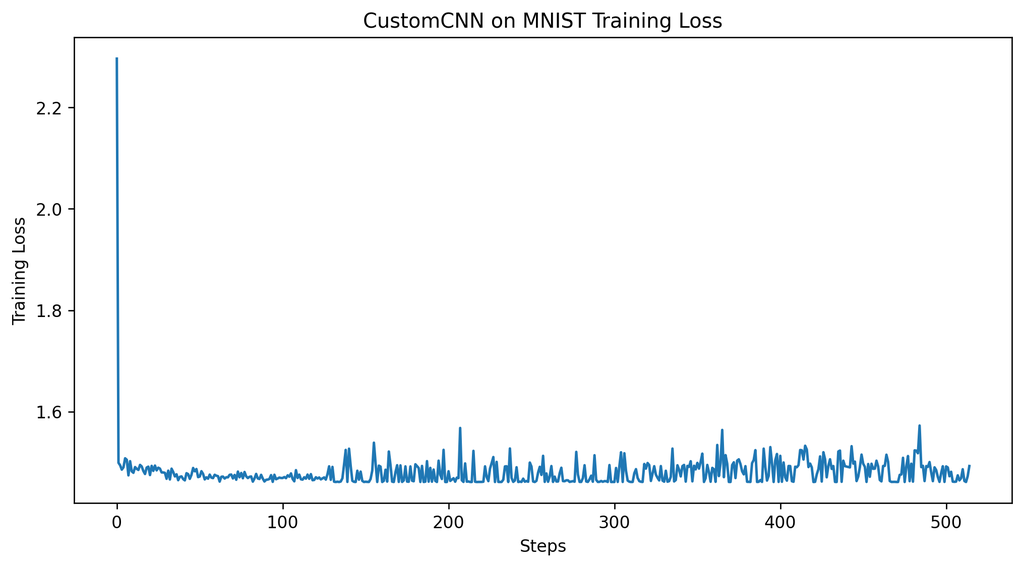

```python
import wandb
from wandb.apis import public
import matplotlib.pyplot as plt

api = public.Api()
run_path = "kndelong/cnn_experiment/nx2e7jmt"
run = api.run(run_path)
history = run.history(pandas=False)

training_loss = [row["Training Loss"] for row in history if "Training Loss" in row]
steps = list(range(len(training_loss)))

plt.figure(figsize=(10, 5))
plt.plot(steps, training_loss)
plt.xlabel("Steps")
plt.ylabel("Training Loss")
plt.title("CustomCNN on MNIST Training Loss")
plt.show()
```

### ResNet-18 & CIFAR-100 Run **(Bouns)**

```python
if __name__ == "__main__":
    wandb.init(project="cnn_experiment")
    main(optimize_hyperparams=False, model_type='ResNet18', dataset='CIFAR100')
```

```
wandb: Currently logged in as: kndelong. Use `wandb login --relogin` to force relogin
```

Tracking run with wandb version 0.14.2

Run data is saved locally in `C:\Users\keagan\wandb\run-20230416_173215-l85reo8v`

Syncing run **[smooth-wildflower-94](https://wandb.ai/kndelong/cnn_experiment/runs/l85reo8v)** to [Weights & Biases](https://wandb.ai/kndelong/cnn_experiment) ([docs](https://wandb.me/run))

View project at https://wandb.ai/kndelong/cnn_experiment

View run at https://wandb.ai/kndelong/cnn_experiment/runs/l85reo8v

```
Files already downloaded and verified
Files already downloaded and verified
Test Accuracy: 81.35%
```

Waiting for W&B process to finish... **(success).**

Run history:

| Test Accuracy | ▁ |
| --- | --- |
| Training Loss | █▅▄▃▃▂▂▂▂▂▂▁▁▁▁▁▁▁▁▁▁▁▁▁▁▁▁▁▁▁▁▁▁▁▁▁▁▁▁▁ |

Run summary:

| Test Accuracy | 81.35 |
| --- | --- |
| Training Loss | 0.05673 |

View run **smooth-wildflower-94** at: https://wandb.ai/kndelong/cnn_experiment/runs/l85reo8v  
Synced 6 W&B file(s), 0 media file(s), 0 artifact file(s) and 0 other file(s)

Find logs at: `.\wandb\run-20230416_173215-l85reo8v\logs`

`optimize_hyperparameters` is set to false in this final run since each run was taking about 25-30 minutes. However, the hyperparameters are manually selected in the `main` method for this run from previous experimental runs.

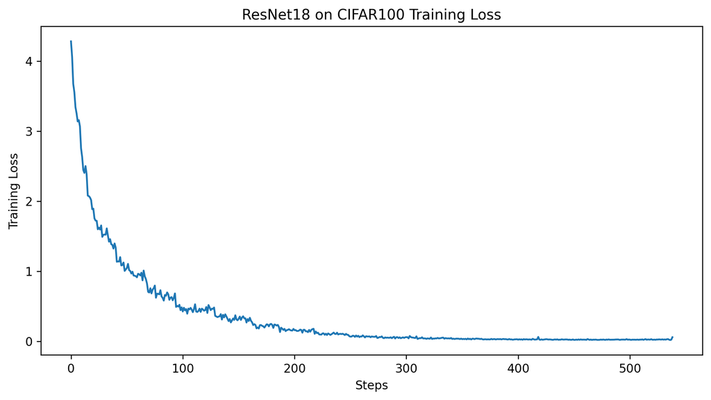

```python
api = public.Api()
run_path = "kndelong/cnn_experiment/l85reo8v"
run = api.run(run_path)
history = run.history(pandas=False)

training_loss = [row["Training Loss"] for row in history if "Training Loss" in row]
steps = list(range(len(training_loss)))

plt.figure(figsize=(10, 5))
plt.plot(steps, training_loss)
plt.xlabel("Steps")
plt.ylabel("Training Loss")
plt.title("ResNet18 on CIFAR100 Training Loss")
plt.show()
```

### Custom ResNet18 & CIFAR100 Run

For fun!

```python
if __name__ == "__main__":
    wandb.init(project="cnn_experiment")
    main(optimize_hyperparams=False, model_type='CustomResNet18', dataset='CIFAR100')
```

Tracking run with wandb version 0.14.2

Run data is saved locally in `C:\Users\keagan\wandb\run-20230416_193142-aqj51cg4`

Syncing run **[effortless-gorge-98](https://wandb.ai/kndelong/cnn_experiment/runs/aqj51cg4)** to [Weights & Biases](https://wandb.ai/kndelong/cnn_experiment) ([docs](https://wandb.me/run))

View project at https://wandb.ai/kndelong/cnn_experiment

View run at https://wandb.ai/kndelong/cnn_experiment/runs/aqj51cg4

```
Files already downloaded and verified
Files already downloaded and verified
Test Accuracy: 7.76%
```

Waiting for W&B process to finish... **(success).**

Run history:

| Test Accuracy | ▁ |
| --- | --- |
| Training Loss | █▇▇▆▆▆▆▄▅▅█▆██▆▅▃▆▂▆▄▆▄▃▅▅▅▇▂▄▅▆▁▄▃▆▄▃▅▃ |

Run summary:

| Test Accuracy | 7.76 |
| --- | --- |
| Training Loss | 4.58499 |

View run **effortless-gorge-98** at: https://wandb.ai/kndelong/cnn_experiment/runs/aqj51cg4  
Synced 6 W&B file(s), 0 media file(s), 0 artifact file(s) and 0 other file(s)

Find logs at: `.\wandb\run-20230416_193142-aqj51cg4\logs`

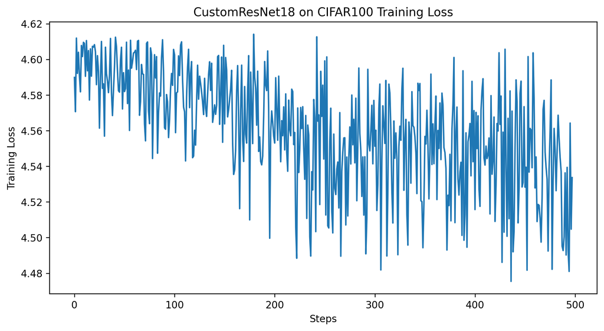

```python
api = public.Api()
run_path = "kndelong/cnn_experiment/aqj51cg4"
run = api.run(run_path)
history = run.history(pandas=False)

training_loss = [row["Training Loss"] for row in history if "Training Loss" in row]
steps = list(range(len(training_loss)))

plt.figure(figsize=(10, 5))
plt.plot(steps, training_loss)
plt.xlabel("Steps")
plt.ylabel("Training Loss")
plt.title("CustomResNet18 on CIFAR100 Training Loss")
plt.show()
```

## Citations

OpenAI. (2021). ChatGPT (Version GPT-4) [Computer software]. OpenAI. https://www.openai.com